# Mapping

## Making maps in R

Maps can be tricky in R! There are many packages to choose from.

- `usmap` is compatible with ggplot
- `maps` is “Base R”
- Some require API keys (e.g., `ggmap`, `tidycensus`)
- Some are interactive (e.g., `leaflet`)
- Some provide utilities (e.g., `tigris`)
- Some deal with raster data (e.g., `terra`)

## What does a map in R look like?

[output not shown]

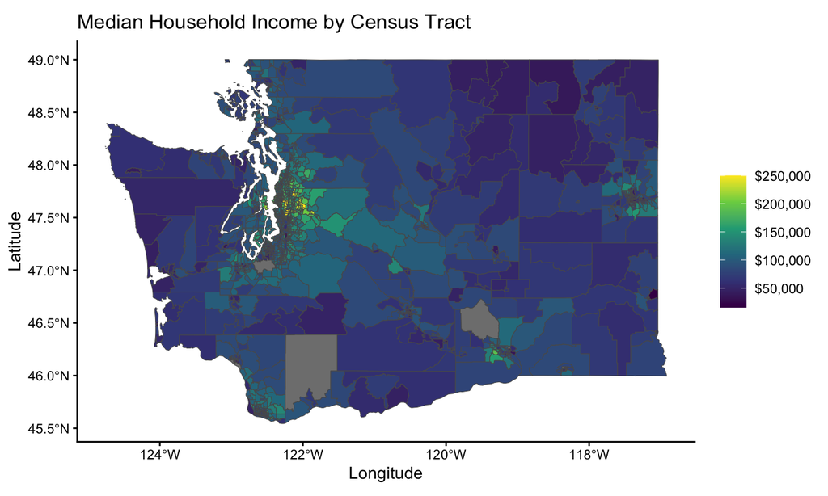

## Data formats - boundary data

```r
library(tidyverse)
head(map_data("county"))
```

```
       long      lat group order  region subregion
1 -86.50517 32.34920     1     1 alabama   autauga
2 -86.53382 32.35493     1     2 alabama   autauga
3 -86.54527 32.36639     1     3 alabama   autauga
4 -86.55673 32.37785     1     4 alabama   autauga
5 -86.57966 32.38357     1     5 alabama   autauga
6 -86.59111 32.37785     1     6 alabama   autauga
```

## Data formats - boundary data

- **`long`**: Longitude (x-coordinate)
- **`lat`**: Latitude (y-coordinate)
- **`group`**: Identifies unique polygons (each county may have multiple polygons if it contains islands or complex borders).
- **`order`**: Sequence in which points should be connected to form the boundary (polygons).
- **`region`**: State name (e.g., “alabama”).
- **`subregion`**: County name within the state (e.g., “autauga”).

## Data formats - sf data

```r
library(usmapdata)
head(us_map("county"))
```

```
Simple feature collection with 6 features and 4 fields
Geometry type: MULTIPOLYGON
Dimension:     XY
Bounding box:  xmin: -2584074 ymin: -2602555 xmax: -1295469 ymax: -2030775
Projected CRS: NAD27 / US National Atlas Equal Area
   fips abbr   full                     county                           geom
1 02013   AK Alaska     Aleutians East Borough MULTIPOLYGON (((-1757988 -2...
2 02016   AK Alaska Aleutians West Census Area MULTIPOLYGON (((-2390688 -2...
3 02020   AK Alaska     Anchorage Municipality MULTIPOLYGON (((-1513326 -2...
4 02050   AK Alaska         Bethel Census Area MULTIPOLYGON (((-1899724 -2...
5 02060   AK Alaska        Bristol Bay Borough MULTIPOLYGON (((-1681144 -2...
6 02063   AK Alaska        Chugach Census Area MULTIPOLYGON (((-1472549 -2...
```

## Data formats - sf data

This data is “Simple Feature” (sf) data used for spatial analysis.

These objects store geometric shapes (like points, lines, or polygons) along with associated attributes (metadata).

the `geom` column is a `MULTIPOLYGON` — a geometry type representing complex shapes, which may consist of multiple polygons (e.g., islands or non-contiguous regions).

Federal Information Processing System (FIPS) Codes for States and Counties are numbers which uniquely identify geographic areas. See [this data key](https://transition.fcc.gov/oet/info/maps/census/fips/fips.txt).

## `ggplot` has spatial functions

`geom_polygon()` works with boundary data

Let’s plot county outlines and major cities.

```r
library(tidyverse) # `map_data()` from ggplot2
library(maps) # `us.cities` data

wa_county <- map_data("county") |> filter(region == "washington")
wa_cities <- us.cities |> filter(country.etc == "WA")

plot_1 <-
  ggplot() +
  geom_polygon(data = wa_county, aes(x = long, y = lat, group = group),
               color = "black", fill = NA) +
  geom_point(data = wa_cities, aes(x = long, y = lat)) +
  labs(title = "Washington State Cities", x = "longitude", y = "latitude") +
  coord_fixed(1.3)
```

## `ggplot` has spatial functions

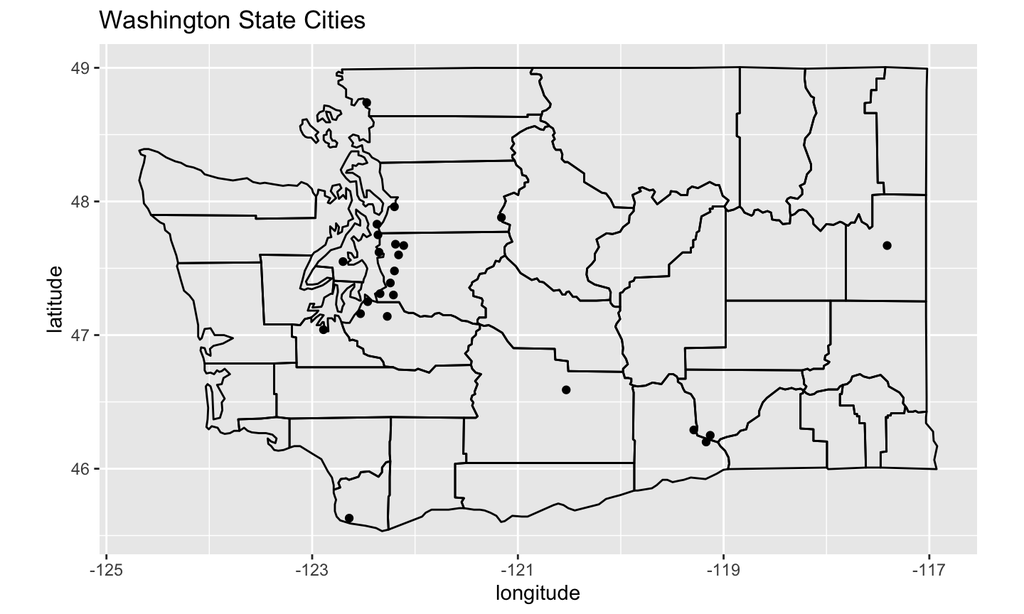

## `maps` package is more similar to Base R

```r
library(maps) # `map` and `map.cities` functions and `us.cities` data

map('county', region = 'washington', col = "#5E610B")
map.cities(us.cities, country="WA", col = "#642EFE", cex = 2)
title(main = "Washington State Cities")
```

## `maps` package is more similar to Base R

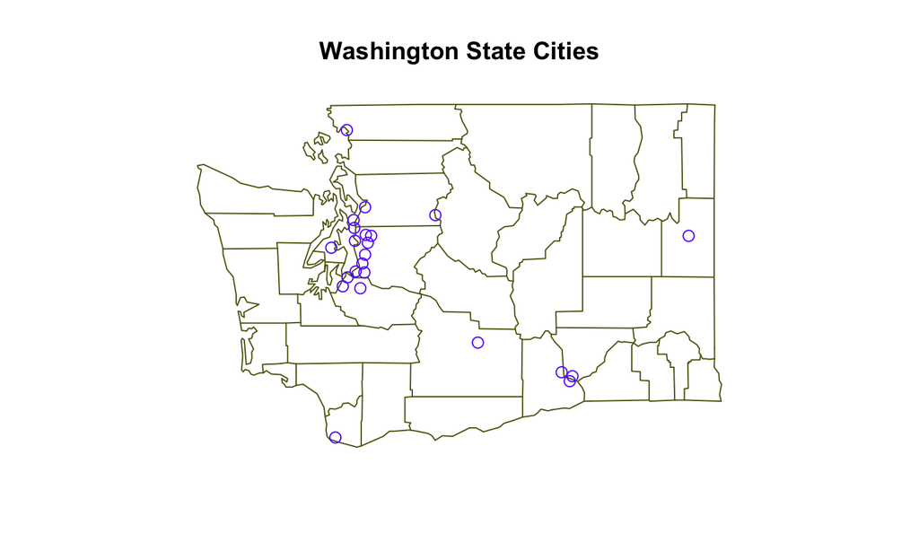

## `usmap` is compatible with ggplot

Let’s fill each county based on its population.

```r
library(tidyverse)
library(usmap) # `countypop` data and the `plot_usmap()` function

wa_dat <- countypop |> filter(abbr == "WA")

plot_3 <-
  plot_usmap(data = wa_dat, values = "pop_2022", include = c("WA")) +
  scale_fill_continuous() +
  theme(legend.position = "right")
```

## `usmap` is compatible with ggplot

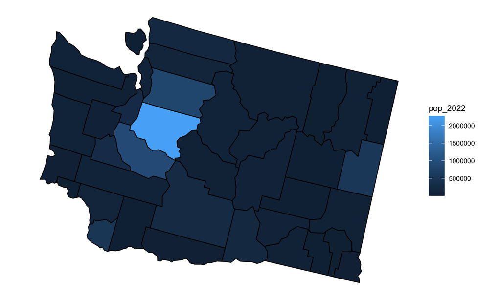

## It can get complicated! `ggplot` fill by county

Sometimes a lot of cleanup is needed to join boundary data with attributes of interest!

```r
library(tidyverse)
library(usmap) # `countypop` data
library(maps) # `us.cities` data

# Get county boundaries
wa_county <- map_data("county") |> filter(region == "washington")

# Get county-level ("subregion") population
wa_dat <- countypop |> filter(abbr == "WA") |>
  mutate(subregion = tolower(str_remove(county, " County"))) |>
  group_by(subregion) |> summarize(pop_2022 = sum(pop_2022))

# Combine the data
wa_complete <- wa_county |> inner_join(wa_dat)

# Get WA cities and their coordinates
wa_cities <- us.cities |> filter(country.etc == "WA")
```

## It can get complicated! `ggplot` fill by county

Sometimes a lot of cleanup is needed to join boundary data with attributes of interest!

```r
# Step 2: create the plot
plot_4 <-
  ggplot() +
  geom_polygon(data = wa_complete,
               aes(x = long, y = lat, group = group, fill = pop_2022)) +
  geom_point(data = wa_cities, aes(x = long, y = lat), color = "red") +
  labs(
    title = "Washington State Population and Cities, 2022",
    x = "longitude", y = "latitude") +
  coord_fixed(1.3)
```

## It can get complicated! `ggplot` fill by county

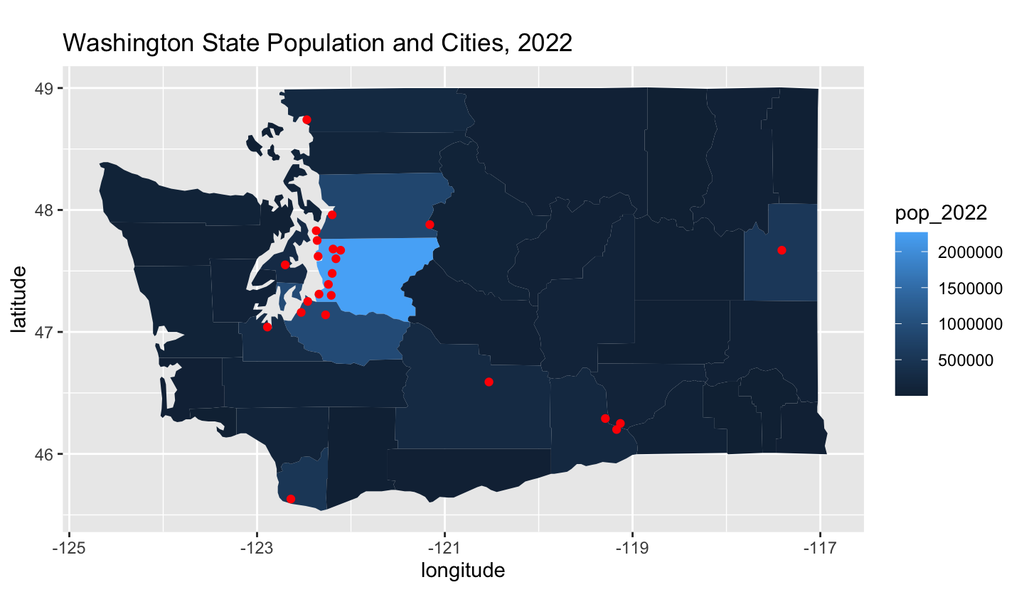

## `tidycensus` is helpful for tract level

Use `geom_sf()` function with SF data.

Let’s fill each census tract by median household income.

```r
library(tidyverse) # `geom_sf()` from ggplot2
library(tidycensus) # `get_acs()` function for American Community Survey data

wa_income <- get_acs(
  geography = "tract",
  variables = "B19013_001", # Median income code
  state = "WA",
  year = 2022,
  geometry = TRUE
)
```

## `tidycensus` is helpful for tract level

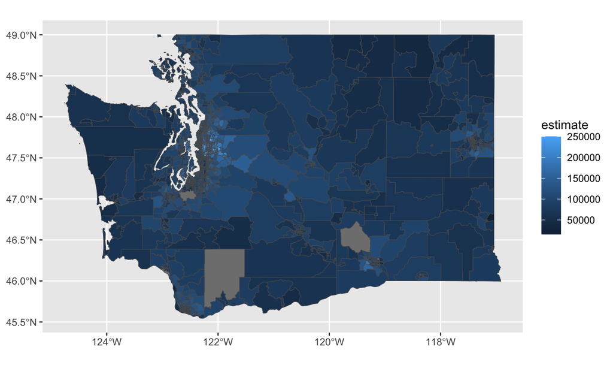

```r
ggplot(data = wa_income, aes(fill = estimate)) +
  geom_sf()
```

## Getting fancier..

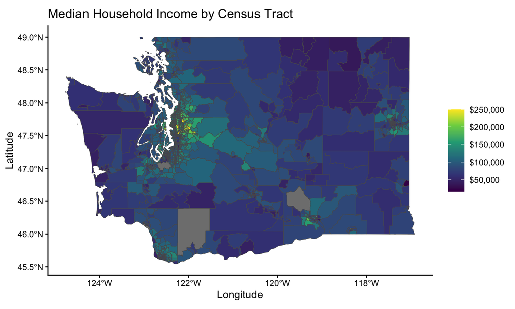

```r
ggplot(data = wa_income, aes(fill = estimate)) +
  geom_sf() +
  labs(title = "Median Household Income by Census Tract",
       x = "Longitude",
       y = "Latitude") +
  theme_classic() +
  scale_fill_viridis_c(labels = scales::label_dollar()) +
  theme(legend.title = element_blank())
```

## More resources

https://rspatial.org/index.html (whole course using `terra`!)

https://rfortherestofus.com/2024/06/us-maps

https://ggplot2-book.org/maps

https://walker-data.com/tidycensus/articles/spatial-data.html

https://walker-data.com/census-r/mapping-census-data-with-r.html

https://jtr13.github.io/cc19/different-ways-of-plotting-u-s-map-in-r.html

## `tigris` has many utility functions

`tigris` gets boundary shapefiles from the US Census Bureau (as sf data).

- `zctas()`: ZIP code tabulation areas
- `voting_districts()`: voting districts
- `school_districts()`: school districts

```r
library(tigris)
zip_wa <- zctas(state = "WA", year = 2010)
```

## Storing API keys safely

**Never EVER put API keys on GitHUB!**

http://api.census.gov/data/key_signup.html

```r
library(tidycensus)
census_api_key("111111abc", install = TRUE)
# First time, reload your environment so you can use the key without restarting R.
readRenviron("~/.Renviron")
# You can check it with:
Sys.getenv("CENSUS_API_KEY")
```

Source: https://walker-data.com/tidycensus/reference/census_api_key.html